# overview

```r
library(bnRep)
```

The R package `bnRep` includes the largest repository of Bayesian networks, which were all collected from recent academic literature in a variety of fields! If you are using any Bayesian network from `bnRep` you should cite:

Leonelli, M (2024). “bnRep: A repository of Bayesian networks from the academic literature.” arXiv preprint arXiv:2409.19158.

```
@Article{,
    title = {bn{R}ep: A repository of {B}ayesian networks from the academic literature},
    author = {Manuele Leonelli},
    journal = {arXiv preprint arXiv:2409.19158},
    year = {2024}
  }
```

## Contribution

If you are interested in having your Bayesian network included in `bnRep` you must prepare three objects:

- the Bayesian network as a `bn.fit` object (if not created with `bnlearn` you can always use import functions, such as `read.bif()`);
- an R file with the same name of the `bn.fit` object reporting the documentation of the Bayesian network;
- a vector/excel file with the required details to include in the `bnRep_summary` object.

You can submit the required objects directly via github (e.g fork/pull), or via email.

If you struggle with any of these steps, please get in touch and I will try to help!

## Overview

`bnRep` includes over 200 Bayesian networks from more than 150 academic publications. It includes discrete, Gaussian and conditional linear Gaussian Bayesian networks, all stored as appropriate `bn.fit` objects from `bnlearn`. They can be exported for use to other software (e.g. Phython libraries) using functions from `bnlearn` such as `write.bif()`. Recall that in order to plot the associated DAG, one must first convert it to a graph object with `bn.net()` from the `bnlearn` package.

### Installation

```r
# Install stable version from CRAN:
install.packages("bnRep")

# Or the development version from GitHub:
remotes::install_github("manueleleonelli/bnRep")
```

### Usage

We will use the `lawschool` Bayesian network as an example. To load it in the environment simply call `data(lawschool)` and to then plot it (for instance using `graphviz.plot` from the `bnlearn` package)

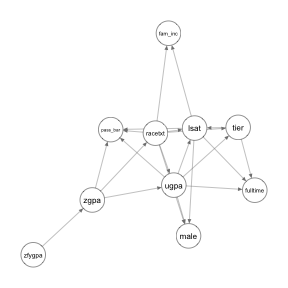

```r
library(bnRep)
library(bnlearn)
data("lawschool")
qgraph::qgraph(bn.net(lawschool))
```

Notice that the function `bn.net` function must be used in order to plot the network.

### Exploring bnRep

Here’s the columns of `bnRep_summary`:

```
#>  [1] "Name"                   "Type"                   "Structure"
#>  [4] "Probabilities"          "Graph"                  "Area"
#>  [7] "Nodes"                  "Arcs"                   "Parameters"
#> [10] "Avg. Parents"           "Max Parents"            "Avg. Levels"
#> [13] "Max Levels"             "Average Markov Blanket" "Year"
#> [16] "Journal"                "Reference"
```

### An overview of the Bayesian networks in bnRep

The following plots show some summary statistics of the repository.

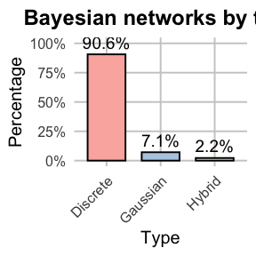

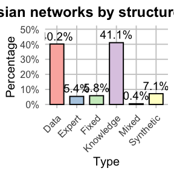

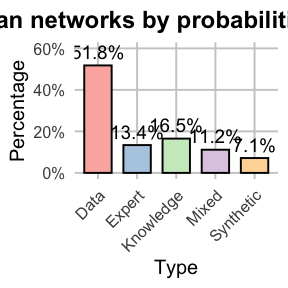

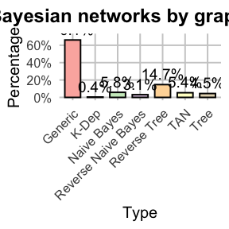

[figure not shown]

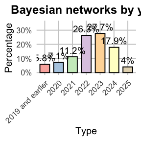

[figure not shown]

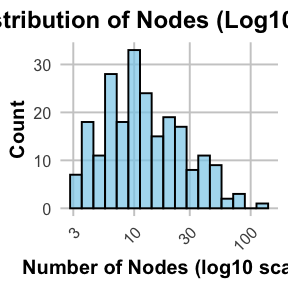

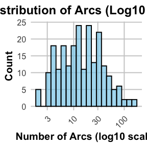